# Properties that affect the duration of riders trip

## Investigation Overview

In this investigation, I was most interested to finding the properties that affected the duration of trips for the users, I assumed that the member birth date would help in determing if there was any age factor involved in users becoming subscribers or just customers, and would also help in determing how long a users trip would take. Other variables of interes would include start date, end date, start time,end time, user_type,member_gender.

## Dataset Overview

The dataset contained 183,412 rows and 16 columns. the attributes included the following:

- duration_sec
- end_station_id
- member_gender
- start_time
- end_station_name
- bike_share_for_all_trip
- end_time
- end_station_latitude
- start_station_id
- end_station_longitude
- start_station_name
- bike_id
- start_station_latitude
- user_type
- start_station_longitude
- member_birth_year

```python
# import all packages and set plots to be embedded inline
import numpy as np
import pandas as pd
import matplotlib.pyplot as plt
import seaborn as sb

%matplotlib inline

# suppress warnings from final output
import warnings
warnings.simplefilter("ignore")
```

```python
# load in the dataset into a pandas dataframe
df = pd.read_csv('201902-fordgobike-tripdata.csv')
print(df.shape)
print(df.dtypes)
df.head(9)
```

```
(183412, 16)
duration_sec                 int64
start_time                  object
end_time                    object
start_station_id           float64
start_station_name          object
start_station_latitude     float64
start_station_longitude    float64
end_station_id             float64
end_station_name            object
end_station_latitude       float64
end_station_longitude      float64
bike_id                      int64
user_type                   object
member_birth_year          float64
member_gender               object
bike_share_for_all_trip     object
dtype: object
```

|  | duration_sec | start_time | end_time | start_station_id | start_station_name | start_station_latitude | start_station_longitude | end_station_id | end_station_name | end_station_latitude | end_station_longitude | bike_id | user_type | member_birth_year | member_gender | bike_share_for_all_trip |
| --- | --- | --- | --- | --- | --- | --- | --- | --- | --- | --- | --- | --- | --- | --- | --- | --- |
| 0 | 52185 | 2019-02-28 17:32:10.1450 | 2019-03-01 08:01:55.9750 | 21.0 | Montgomery St BART Station (Market St at 2nd St) | 37.789625 | -122.400811 | 13.0 | Commercial St at Montgomery St | 37.794231 | -122.402923 | 4902 | Customer | 1984.0 | Male | No |
| 1 | 42521 | 2019-02-28 18:53:21.7890 | 2019-03-01 06:42:03.0560 | 23.0 | The Embarcadero at Steuart St | 37.791464 | -122.391034 | 81.0 | Berry St at 4th St | 37.775880 | -122.393170 | 2535 | Customer | NaN | NaN | No |
| 2 | 61854 | 2019-02-28 12:13:13.2180 | 2019-03-01 05:24:08.1460 | 86.0 | Market St at Dolores St | 37.769305 | -122.426826 | 3.0 | Powell St BART Station (Market St at 4th St) | 37.786375 | -122.404904 | 5905 | Customer | 1972.0 | Male | No |
| 3 | 36490 | 2019-02-28 17:54:26.0100 | 2019-03-01 04:02:36.8420 | 375.0 | Grove St at Masonic Ave | 37.774836 | -122.446546 | 70.0 | Central Ave at Fell St | 37.773311 | -122.444293 | 6638 | Subscriber | 1989.0 | Other | No |
| 4 | 1585 | 2019-02-28 23:54:18.5490 | 2019-03-01 00:20:44.0740 | 7.0 | Frank H Ogawa Plaza | 37.804562 | -122.271738 | 222.0 | 10th Ave at E 15th St | 37.792714 | -122.248780 | 4898 | Subscriber | 1974.0 | Male | Yes |
| 5 | 1793 | 2019-02-28 23:49:58.6320 | 2019-03-01 00:19:51.7600 | 93.0 | 4th St at Mission Bay Blvd S | 37.770407 | -122.391198 | 323.0 | Broadway at Kearny | 37.798014 | -122.405950 | 5200 | Subscriber | 1959.0 | Male | No |
| 6 | 1147 | 2019-02-28 23:55:35.1040 | 2019-03-01 00:14:42.5880 | 300.0 | Palm St at Willow St | 37.317298 | -121.884995 | 312.0 | San Jose Diridon Station | 37.329732 | -121.901782 | 3803 | Subscriber | 1983.0 | Female | No |
| 7 | 1615 | 2019-02-28 23:41:06.7660 | 2019-03-01 00:08:02.7560 | 10.0 | Washington St at Kearny St | 37.795393 | -122.404770 | 127.0 | Valencia St at 21st St | 37.756708 | -122.421025 | 6329 | Subscriber | 1989.0 | Male | No |
| 8 | 1570 | 2019-02-28 23:41:48.7900 | 2019-03-01 00:07:59.7150 | 10.0 | Washington St at Kearny St | 37.795393 | -122.404770 | 127.0 | Valencia St at 21st St | 37.756708 | -122.421025 | 6548 | Subscriber | 1988.0 | Other | No |

```python
new_df = df.copy()
new_df = pd.DataFrame(new_df)
new_df['time_start'] = new_df['start_time'].apply(lambda x:x.split()[1])
new_df['start_date'] = new_df['start_time'].apply(lambda x:x.split()[0])
new_df['time_end'] = new_df['end_time'].apply(lambda x:x.split()[1])
new_df['end_date'] = new_df['end_time'].apply(lambda x:x.split()[0])
new_df.drop(columns = ['start_time','end_time'],inplace=True)
```

```python
#changing the data types of columns
variables = ['start_station_id','start_station_latitude','start_station_longitude','end_station_id','end_station_latitude',
            'end_station_longitude','bike_id','member_birth_year']
for var in variables:
    new_df[var] = new_df[var].astype('object')
new_df['start_date'] = pd.to_datetime(new_df['start_date'])
new_df['end_date'] = pd.to_datetime(new_df['end_date'])
```

```python
# handling the null values
new_df['member_gender'].fillna('Unknown',inplace=True)
new_df = new_df[~new_df['member_birth_year'].isnull()]
```

> Note that the above cells have been set as "Skip"-type slides. That means that when the notebook is rendered as http slides, those cells won't show up.

> **Rubric Tip**: Provide at least 3 **polished** visualizations to convey key insights. The total number of visualizations in the slideshow shoould be less than 50% of the number of visualizations in the exploratory analysis. For example, if the exploratory analysis (Part I) has 18 visualizations, the slideshow can have (3 - 8) visualizations.

> **Rubric Tip**: Each visualization in the slideshow is associated with **descriptive comments** that accurately depict their purpose and your observation.

> **Rubric Tip**: All plots in the slideshow are appropriate, meaning the plot type, encodings, and transformations are suitable to the underlying data.

> **Rubric Tip**: All plots in the slideshow are polished, meaning all plots have a title, labeled x/y axes (with units), x/y ticks, and legends.

## Distribution of Duration seconds

The distribution of the duration_seconds is right skewed, it is unimodal with majority falling within 60 to 1000,and the less amount from 3k upwards.

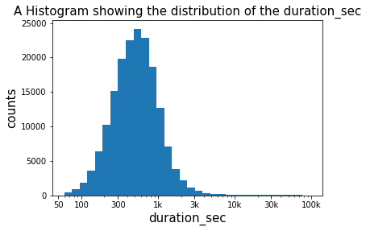

```python
# creating a histogram to show the distribution of duration_sec
bins=10**np.arange(1.78,4.92+0.1,0.1)
plt.hist(data=new_df,x='duration_sec',bins=bins);
plt.xscale('log')
ticks=[50,100,300,1000,3000,10000,30000,100000]
labels = ['50','100','300','1k','3k','10k','30k','100k']
plt.xticks(ticks,labels);
plt.xlabel('duration_sec',size=15);
plt.ylabel('counts',size=15)
plt.title('A Histogram showing the distribution of the duration_sec',size=15,loc='center');
```

```python
# to remove outliers present in the duration_sec
new_df = new_df[new_df['duration_sec'] <5000]
```

```python
new_df['member_age'] = 2022 - new_df['member_birth_year']
print(new_df['member_age'].max())
print(new_df['member_age'].min())
new_df['member_age'] = new_df['member_age'].astype(int)
new_df['member_age'].describe()
```

```
144.0
21.0
```

```
count    175147.000000
mean         37.193563
std          10.116689
min          21.000000
25%          30.000000
50%          35.000000
75%          42.000000
max         144.000000
Name: member_age, dtype: float64
```

```python
new_df = new_df[new_df['member_age'] < 85]
new_df['member_age'].max()
age_order = new_df['member_age'].value_counts(sort=False)
```

## Distribution of ages of the riders

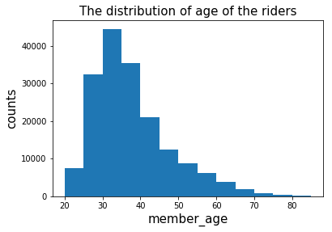

```python
bins = np.arange(20,84+5,5)
#plotting a histogram to see the distribution of ages
plt.hist(x=new_df['member_age'],bins=bins);
plt.xlabel('member_age',size=15);
plt.ylabel('counts',size=15);
plt.title('The distribution of age of the riders',size=15);
```

## Counts of trips on each day

Most bike ride started on the 28th of febuary 2019 with a value of around 10,00 rides(maybe there was an awareness!), the smallest being on the 9th of feburary with a value around 2500. I wonder how this counts played out within the week. days such as 5th-7th and 19th-21th had this large hikes in number of rides it could be work looking into if there was a holiday or awareness program

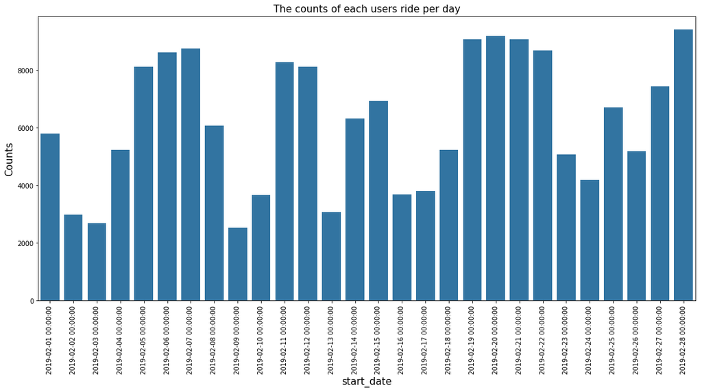

```python
# plotting a countplot for each start date
base_color = sb.color_palette()[0]
order = new_df['start_date'].sort_index(ascending=False).reset_index()
order=order.groupby('start_date').size().index
order = order
plt.figure(figsize=[18,8])
sb.countplot(data=new_df,x=new_df['start_date'],color=base_color,order=order);
plt.xticks(rotation=90);
plt.xlabel('start_date',size=15);
plt.ylabel('Counts',size=15);
plt.title('The counts of each users ride per day',size=15);
```

## member_age vs duration_sec

There is a weak relationship between age and duration_seconds but the duration of trips reduces as the age increases

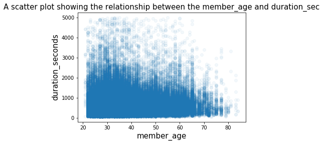

```python
#plotting a scatter plot of member_age against the duration_seconds
plt.scatter(data=new_df,x='member_age',y='duration_sec',alpha=1/20);
plt.xlabel('member_age',size=15);
plt.ylabel('duration_seconds',size=15);
plt.title('A scatter plot showing the relationship between the member_age and duration_sec',size=15);
```

## member gender vs user type

The subscriber is more than the customers in the ford bike dataset, but here we are ableto see how they spread across the member genders, with a noticable difference between the subscribers and the customers for each gender

[figure not shown]

```python
#checking the relationship between the user type and member gender
sb.countplot(data=new_df,x='member_gender',hue='user_type');
plt.title('The count of users based on gender and user_type',size=15);
```

## Average duration of trips that was made on each day

I plotted the day of week alongside the start date to check for any relationship between the day and the duration_seconds, and we see that the longest average trip was on a sunday. we see the other two spikes on the 10th and 23rd of feburary was a sunday and saturday respectively, users on weekends tends to have longer ride periods than on weekdays.

```python
def week_number_of_month(date_value):
    """this fumction derives the week of the month for each month of the start date.
        @isocalender: return a tuple of the date broken into year, week number and weekday
        @replace(day=1): replace the date with the first day of each month in that year"""
    return (date_value.isocalendar()[1] - date_value.replace(day=1).isocalendar()[1] + 1)
```

```python
new_df['week_number'] = new_df['start_date'].apply(week_number_of_month)
# plotting a count plot for each week of the start date
#plt.figure(figsize=[18,8])
#sb.countplot(data=new_df,x='week_number',color=base_color)
#plt.xlabel('week_number',size=8)
#plt.ylabel('count',size=8)
#plt.title('The counts of each users ride per week',size=15)
```

```python
# creating a column that identifies the day of the week from start date.
import calendar
def weekday_name(date):
    """this function extracts the day of the week from the date values
      @date: this is the date value passed in to the function
      @weekday(): this creates the day of the week but records it as a number
      @calendar.day_name: this then converts the numbers from the weekday function into weekday names"""
    record = date.weekday()
    return calendar.day_name[record]
new_df['dow'] = new_df['start_date'].apply(weekday_name) + " " +'wk'+(new_df['week_number'].astype('str'))
new_df['dow'] = new_df['dow'].apply(lambda x:x.lower())
new_df.head(10)
```

|  | duration_sec | start_station_id | start_station_name | start_station_latitude | start_station_longitude | end_station_id | end_station_name | end_station_latitude | end_station_longitude | bike_id | ... | member_birth_year | member_gender | bike_share_for_all_trip | time_start | start_date | time_end | end_date | member_age | week_number | dow |
| --- | --- | --- | --- | --- | --- | --- | --- | --- | --- | --- | --- | --- | --- | --- | --- | --- | --- | --- | --- | --- | --- |
| 4 | 1585 | 7 | Frank H Ogawa Plaza | 37.8046 | -122.272 | 222 | 10th Ave at E 15th St | 37.7927 | -122.249 | 4898 | ... | 1974 | Male | Yes | 23:54:18.5490 | 2019-02-28 | 00:20:44.0740 | 2019-03-01 | 48 | 5 | thursday wk5 |
| 5 | 1793 | 93 | 4th St at Mission Bay Blvd S | 37.7704 | -122.391 | 323 | Broadway at Kearny | 37.798 | -122.406 | 5200 | ... | 1959 | Male | No | 23:49:58.6320 | 2019-02-28 | 00:19:51.7600 | 2019-03-01 | 63 | 5 | thursday wk5 |
| 6 | 1147 | 300 | Palm St at Willow St | 37.3173 | -121.885 | 312 | San Jose Diridon Station | 37.3297 | -121.902 | 3803 | ... | 1983 | Female | No | 23:55:35.1040 | 2019-02-28 | 00:14:42.5880 | 2019-03-01 | 39 | 5 | thursday wk5 |
| 7 | 1615 | 10 | Washington St at Kearny St | 37.7954 | -122.405 | 127 | Valencia St at 21st St | 37.7567 | -122.421 | 6329 | ... | 1989 | Male | No | 23:41:06.7660 | 2019-02-28 | 00:08:02.7560 | 2019-03-01 | 33 | 5 | thursday wk5 |
| 8 | 1570 | 10 | Washington St at Kearny St | 37.7954 | -122.405 | 127 | Valencia St at 21st St | 37.7567 | -122.421 | 6548 | ... | 1988 | Other | No | 23:41:48.7900 | 2019-02-28 | 00:07:59.7150 | 2019-03-01 | 34 | 5 | thursday wk5 |
| 9 | 1049 | 19 | Post St at Kearny St | 37.789 | -122.403 | 121 | Mission Playground | 37.7592 | -122.421 | 6488 | ... | 1992 | Male | No | 23:49:47.6990 | 2019-02-28 | 00:07:17.0250 | 2019-03-01 | 30 | 5 | thursday wk5 |
| 10 | 458 | 370 | Jones St at Post St | 37.7873 | -122.413 | 43 | San Francisco Public Library (Grove St at Hyde... | 37.7788 | -122.416 | 5318 | ... | 1996 | Female | Yes | 23:57:57.2110 | 2019-02-28 | 00:05:35.4350 | 2019-03-01 | 26 | 5 | thursday wk5 |
| 11 | 506 | 44 | Civic Center/UN Plaza BART Station (Market St ... | 37.7811 | -122.412 | 343 | Bryant St at 2nd St | 37.7832 | -122.394 | 5848 | ... | 1993 | Male | No | 23:56:55.5400 | 2019-02-28 | 00:05:21.7330 | 2019-03-01 | 29 | 5 | thursday wk5 |
| 12 | 1176 | 127 | Valencia St at 21st St | 37.7567 | -122.421 | 323 | Broadway at Kearny | 37.798 | -122.406 | 5328 | ... | 1990 | Male | No | 23:45:12.6510 | 2019-02-28 | 00:04:49.1840 | 2019-03-01 | 32 | 5 | thursday wk5 |
| 14 | 395 | 243 | Bancroft Way at College Ave | 37.8694 | -122.254 | 252 | Channing Way at Shattuck Ave | 37.8658 | -122.267 | 4786 | ... | 1988 | Male | No | 23:56:26.8480 | 2019-02-28 | 00:03:01.9470 | 2019-03-01 | 34 | 5 | thursday wk5 |

10 rows × 21 columns

```python
day_cat = ['sunday wk1','friday wk1','saturday wk1','sunday wk2','monday wk2','tuesday wk2','wednesday wk2','thursday wk2',
           'friday wk2','saturday wk2','sunday wk3','monday wk3','tuesday wk3','wednesday wk3','thursday wk3','friday wk3',
          'saturday wk3','sunday wk4','monday wk4','tuesday wk4','wednesday wk4','thursday wk4','friday wk4','saturday wk4',
          'monday wk5','tuesday wk5','wednesday wk5','thursday wk5']
day_order = pd.api.types.CategoricalDtype(categories=day_cat,ordered=True)
new_df['dow'] = new_df['dow'].astype(day_order)
```

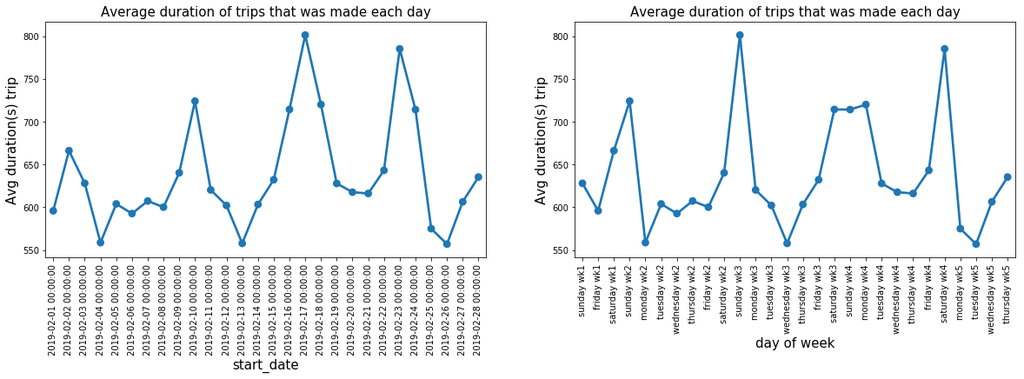

```python
order = new_df['start_date'].sort_index(ascending=False).reset_index()
order=order.groupby('start_date').size().index
plt.figure(figsize=[20,5])
plt.subplot(1,2,1)
sb.pointplot(data=new_df,x=new_df['start_date'].astype('object'),y='duration_sec',order=order,ci=0)
plt.xticks(rotation=90)
plt.title('Average duration of trips that was made each day',size=15,loc='center')
plt.ylabel('Avg duration(s) trip',size=15);
plt.xlabel('start_date',size=15);
plt.subplot(1,2,2)
sb.pointplot(data=new_df,x='dow',y='duration_sec',ci=0)
plt.xticks(rotation=90)
plt.ylabel('Avg duration(s) trip',size=15);
plt.xlabel('day of week',size=15)
plt.title('Average duration of trips that was made each day',size=15,loc='center');
```

## Avg duration vs day of week for each gender

> We clearly see again that female gender had longer rides than males.  
> Longer rides occurred during the weekends.

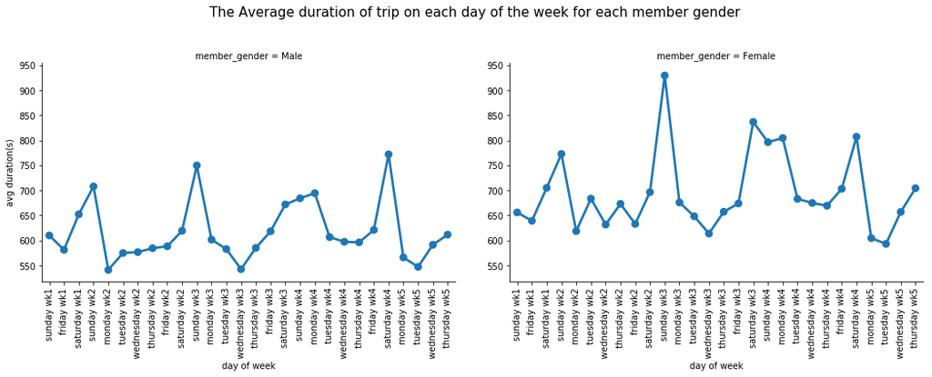

```python
new_df = new_df[new_df['member_gender'].isin(['Male','Female'])]
gender_order = new_df['member_gender'].value_counts()
# I would plot a facet grid to show the duration seconds on each day of the week by the gender, maybe this would clearly tell us
# the relationships between this three variables if there is any
plt.figure(figsize=[20,4]);
g = sb.FacetGrid(data=new_df,col='member_gender',size=5,aspect=1.5);
g.map(sb.pointplot,'dow','duration_sec',ci=0);
g.set_xticklabels(rotation=90);
g.fig.subplots_adjust(top=0.8);
g.fig.suptitle('The Average duration of trip on each day of the week for each member gender',size=15);
g.set_axis_labels('day of week','avg duration(s)');
```

# duration vs member age for each user type

We see how majority of customers age was within 21-40 which is why they have longer rides because they are younger an probably haven't been using the service as often as out older users which is why they have not become subscribe users yet, we see the reduction in duration_sec for older user, most of which are subscribers

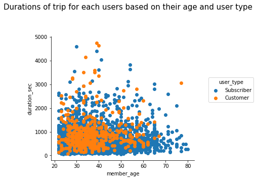

```python
# plotting the duration_sec against the age and user type
# I would select a smaller sample size to avoid overplotting
samples = np.random.choice(new_df.shape[0],5000,replace=True)
df_samples = new_df.loc[samples,:]
g = sb.FacetGrid(data=df_samples,hue='user_type',size=5);
g.map(plt.scatter,'member_age','duration_sec');
g.add_legend();
g.fig.subplots_adjust(top=0.8)
g.fig.suptitle('Durations of trip for each users based on their age and user type',size=15);
```

### Generate Slideshow

Once you're ready to generate your slideshow, use the `jupyter nbconvert` command to generate the HTML slide show.

```python
# Use this command if you are running this file in local
!jupyter nbconvert Part_II_slide_deck_template.ipynb --to slides --post serve --no-input --no-prompt
```

[output not shown]

> In the classroom workspace, the generated HTML slideshow will be placed in the home folder.

> In local machines, the command above should open a tab in your web browser where you can scroll through your presentation. Sub-slides can be accessed by pressing 'down' when viewing its parent slide. Make sure you remove all of the quote-formatted guide notes like this one before you finish your presentation! At last, you can stop the Kernel.

### Submission

If you are using classroom workspace, you can choose from the following two ways of submission:

1. **Submit from the workspace**. Make sure you have removed the example project from the /home/workspace directory. You must submit the following files:
   - Part_I_notebook.ipynb
   - Part_I_notebook.html or pdf
   - Part_II_notebook.ipynb
   - Part_I_slides.html
   - README.md
   - dataset (optional)
1. **Submit a zip file on the last page of this project lesson**. In this case, open the Jupyter terminal and run the command below to generate a ZIP file.

   ```
   zip -r my_project.zip .
   ```

   The command abobve will ZIP every file present in your /home/workspace directory. Next, you can download the zip to your local, and follow the instructions on the last page of this project lesson.